# Katelyn Tolbert - Particle Health - Technical Assessment

In order to build a model for years, both the test and train dataset were cleaned up to ensure all years in the testing set were present in training, and vice versa.

```python
# Create a list of unique years present in the 'test' DataFrame
test_years = test['year'].unique()
train_years = train['year'].unique()

# Filter the 'train' DataFrame to include only the rows with years that are present in 'test'
train_filtered = train[train['year'].isin(test_years)]
test_filtered = test[test['year'].isin(train_years)]
```

```python
test_filtered.year.value_counts()
```

```
2007    4029
2006    3710
2008    3516
2005    3498
2009    3131
        ...
1930       2
1944       1
1943       1
1941       1
1934       1
Name: year, Length: 78, dtype: int64
```

```python
train_filtered.year.value_counts()
```

```
2007    35375
2006    33824
2005    31454
2008    31244
2009    27907
        ...
1936       22
1942       21
1944       14
1940       14
1943       13
Name: year, Length: 78, dtype: int64
```

We can see from the plot below that there is quite the imbalance in observations per year, peaking in the 2000s. This was highlighted in the data description, but it's always good to visualize. We can see that the training data is representative to the imbalance seen within the test set.

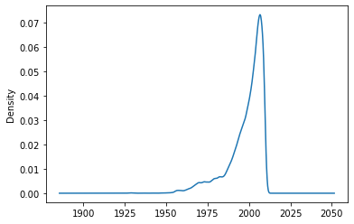

```python
train_filtered.year.plot.density()
```

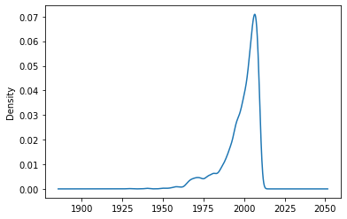

```python
test_filtered.year.plot.density()
```

As there are 90 features, visualizing them all one by one is possible but not a terrifically feasible way to quickly digest the information. A quick glance at the first 25 features below, may possibly indicate more variation in the features as we increase in decades, indicating that we may be able to better predict songs in later decades due to wider ranges in these features not seen in earlier years. Visualizing the first 25 features allows us to see the data for both the "average timbre" (features 0-11) and "timbre covariance" features (12-89).

[figure not shown]

```python
# Get the first 25 feature columns for plotting
num_features_to_plot = 25
features_to_plot = [f'feature_{i}' for i in range(num_features_to_plot)]

# Create subplots with 5 plots in each row
num_rows = 5
num_cols = num_features_to_plot // num_rows
fig, axes = plt.subplots(num_rows, num_cols, figsize=(15, 15), sharey=True)

# Flatten the axes array for easy plotting
axes = axes.flatten()

# Scatter plots of the first 25 features against the target variable 'year'
for i, feature in enumerate(features_to_plot):
    sns.scatterplot(data=df, x=feature, y='year', alpha=0.3, ax=axes[i])
    axes[i].set_xlabel(feature)
    if i % num_cols == 0:
        axes[i].set_ylabel('De')

plt.tight_layout()
plt.show()
```

From looking at the scatter plots above, it doesn't appear that there are linear relationships between the target variable and the features, but we can test for this. Below, we use the pearson correlation to check for linear and spearman for monotonic.

The background is colored according to gradient to help quickly visualize a sense of magnitude of correlation and the direction. The darker blue means higher positive corrleation and the darker red indicates higher negative correlation.

```python
(train_filtered
.corr(method='pearson')
.style
.background_gradient(cmap='RdBu', vmin=-1, vmax=1)
)
```

|  | year | feature_0 | feature_1 | feature_2 | feature_3 | feature_4 | feature_5 | feature_6 | feature_7 | feature_8 | feature_9 | feature_10 | feature_11 | feature_12 | feature_13 | feature_14 | feature_15 | feature_16 | feature_17 | feature_18 | feature_19 | feature_20 | feature_21 | feature_22 | feature_23 | feature_24 | feature_25 | feature_26 | feature_27 | … |
| --- | --- | --- | --- | --- | --- | --- | --- | --- | --- | --- | --- | --- | --- | --- | --- | --- | --- | --- | --- | --- | --- | --- | --- | --- | --- | --- | --- | --- | --- | --- |
| year | 1.000000 | 0.225820 | 0.018749 | -0.136438 | -0.003051 | 0.017073 | -0.185962 | 0.108811 | -0.033675 | -0.021902 | 0.036627 | 0.028998 | -0.096794 | 0.022072 | 0.078557 | -0.008154 | 0.033574 | 0.028957 | 0.022226 | -0.004024 | 0.086925 | -0.057127 | 0.049169 | 0.047251 | -0.058082 | 0.064890 | -0.017582 | -0.022942 | 0.007344 | … |
| feature_0 | 0.225820 | 1.000000 | 0.560782 | 0.249089 | 0.023336 | -0.286832 | -0.264938 | 0.170328 | -0.056485 | 0.220938 | 0.104806 | 0.060994 | -0.134468 | -0.358096 | -0.438532 | -0.445782 | -0.370971 | -0.390584 | -0.287336 | -0.436060 | -0.318144 | -0.482067 | -0.298397 | -0.250559 | -0.432983 | 0.108150 | -0.146139 | -0.169553 | 0.070967 | … |
| feature_1 | 0.018749 | 0.560782 | 1.000000 | 0.022503 | 0.128858 | -0.187834 | -0.110313 | 0.116318 | 0.110661 | 0.127089 | 0.373313 | -0.088615 | -0.057029 | -0.160225 | -0.277428 | -0.167475 | -0.107740 | -0.186519 | -0.028440 | -0.189969 | -0.100936 | -0.331803 | -0.082532 | 0.004950 | -0.281303 | -0.089859 | -0.043976 | -0.188968 | 0.143254 | … |
| feature_2 | -0.136438 | 0.249089 | 0.022503 | 1.000000 | 0.152466 | -0.133764 | 0.037156 | -0.056150 | 0.078307 | 0.044737 | -0.092485 | 0.044049 | -0.019859 | -0.074283 | -0.237826 | -0.200120 | -0.293671 | -0.114334 | -0.388422 | -0.119003 | -0.374707 | -0.043710 | -0.351335 | -0.298509 | -0.014810 | -0.050426 | 0.032214 | 0.207363 | 0.115920 | … |
| feature_3 | -0.003051 | 0.023336 | 0.128858 | 0.152466 | 1.000000 | 0.031429 | 0.322536 | 0.282518 | 0.028563 | -0.037228 | 0.165582 | 0.310249 | -0.102973 | -0.025169 | 0.149802 | 0.270266 | 0.355416 | 0.148403 | 0.516188 | 0.153225 | 0.301491 | 0.013224 | 0.300819 | 0.435372 | 0.036587 | -0.029077 | 0.096364 | -0.358459 | -0.020342 | … |
| feature_4 | 0.017073 | -0.286832 | -0.187834 | -0.133764 | 0.031429 | 1.000000 | 0.016224 | -0.106184 | -0.011721 | -0.217989 | -0.104765 | 0.015184 | 0.031019 | 0.146516 | 0.217424 | 0.254686 | 0.225731 | 0.198595 | 0.168720 | 0.327019 | 0.240836 | 0.239726 | 0.254111 | 0.181584 | 0.289013 | -0.065466 | 0.023354 | 0.112568 | -0.004225 | … |
| feature_5 | -0.185962 | -0.264938 | -0.110313 | 0.037156 | 0.322536 | 0.016224 | 1.000000 | -0.248667 | 0.013391 | -0.040765 | -0.040502 | -0.333992 | 0.149005 | 0.078213 | 0.115415 | 0.265686 | 0.563593 | 0.186759 | 0.647876 | 0.308013 | 0.484590 | 0.285625 | 0.572252 | 0.621608 | 0.195405 | -0.079039 | 0.053402 | -0.270500 | 0.003532 | … |
| feature_6 | 0.108811 | 0.170328 | 0.116318 | -0.056150 | 0.282518 | -0.106184 | -0.248667 | 1.000000 | 0.168729 | -0.102146 | 0.011503 | -0.109380 | -0.179528 | -0.047696 | -0.015325 | 0.027363 | -0.072922 | -0.046000 | 0.028025 | -0.057261 | -0.039481 | -0.126729 | -0.030274 | -0.025982 | -0.096440 | 0.044410 | -0.045466 | -0.080035 | -0.052173 | … |
| feature_7 | -0.033675 | -0.056485 | 0.110661 | 0.078307 | 0.028563 | -0.011721 | 0.013391 | 0.168729 | 1.000000 | -0.181325 | 0.415205 | -0.236146 | -0.054766 | 0.024742 | 0.023093 | 0.093675 | 0.140459 | 0.042810 | 0.109778 | 0.069664 | 0.012118 | 0.026036 | -0.038528 | 0.141779 | -0.014490 | -0.093464 | 0.106942 | 0.034470 | -0.004372 | … |
| feature_8 | -0.021902 | 0.220938 | 0.127089 | 0.044737 | -0.037228 | -0.217989 | -0.040765 | -0.102146 | -0.181325 | 1.000000 | 0.341579 | -0.058890 | 0.088627 | -0.106183 | -0.117625 | -0.136440 | -0.107973 | -0.138210 | -0.076176 | -0.118119 | -0.142565 | -0.135718 | -0.145554 | -0.074464 | -0.094994 | 0.080278 | 0.007777 | -0.090425 | 0.092148 | … |
| feature_9 | 0.036627 | 0.104806 | 0.373313 | -0.092485 | 0.165582 | -0.104765 | -0.040502 | 0.011503 | 0.415205 | 0.341579 | 1.000000 | -0.162316 | -0.077149 | -0.089708 | -0.061826 | 0.030392 | 0.130577 | -0.002312 | 0.185441 | 0.034091 | 0.056625 | -0.069900 | 0.023048 | 0.198198 | -0.087601 | -0.117255 | 0.071529 | -0.123857 | 0.054429 | … |
| feature_10 | 0.028998 | 0.060994 | -0.088615 | 0.044049 | 0.310249 | 0.015184 | -0.333992 | -0.109380 | -0.236146 | -0.058890 | -0.162316 | 1.000000 | 0.206649 | -0.085860 | 0.009713 | -0.044616 | -0.239145 | -0.057516 | -0.168858 | -0.141143 | -0.194289 | -0.157776 | -0.209976 | -0.231855 | -0.074455 | 0.057895 | 0.033754 | -0.019190 | -0.034831 | … |
| feature_11 | -0.096794 | -0.134468 | -0.057029 | -0.019859 | -0.102973 | 0.031019 | 0.149005 | -0.179528 | -0.054766 | 0.088627 | -0.077149 | 0.206649 | 1.000000 | 0.032393 | 0.055149 | 0.013921 | 0.069691 | -0.041521 | 0.022973 | 0.069894 | 0.026307 | 0.090053 | 0.047552 | 0.050522 | 0.059476 | -0.003660 | 0.057098 | 0.017951 | 0.020976 | … |
| feature_12 | 0.022072 | -0.358096 | -0.160225 | -0.074283 | -0.025169 | 0.146516 | 0.078213 | -0.047696 | 0.024742 | -0.106183 | -0.089708 | -0.085860 | 0.032393 | 1.000000 | 0.424471 | 0.386925 | 0.268482 | 0.327208 | 0.175086 | 0.268405 | 0.200709 | 0.277610 | 0.164758 | 0.167579 | 0.228774 | 0.141722 | 0.182110 | 0.115612 | -0.027867 | … |
| feature_13 | 0.078557 | -0.438532 | -0.277428 | -0.237826 | 0.149802 | 0.217424 | 0.115415 | -0.015325 | 0.023093 | -0.117625 | -0.061826 | 0.009713 | 0.055149 | 0.424471 | 1.000000 | 0.508589 | 0.418497 | 0.492346 | 0.337710 | 0.432946 | 0.480811 | 0.434393 | 0.444884 | 0.346814 | 0.347175 | 0.251176 | 0.255905 | 0.090611 | -0.103975 | … |
| feature_14 | -0.008154 | -0.445782 | -0.167475 | -0.200120 | 0.270266 | 0.254686 | 0.265686 | 0.027363 | 0.093675 | -0.136440 | 0.030392 | -0.044616 | 0.013921 | 0.386925 | 0.508589 | 1.000000 | 0.545741 | 0.541160 | 0.485434 | 0.573236 | 0.460129 | 0.443269 | 0.445764 | 0.468330 | 0.433850 | 0.028979 | 0.300046 | 0.171787 | 0.030667 | … |
| feature_15 | 0.033574 | -0.370971 | -0.107740 | -0.293671 | 0.355416 | 0.225731 | 0.563593 | -0.072922 | 0.140459 | -0.107973 | 0.130577 | -0.239145 | 0.069691 | 0.268482 | 0.418497 | 0.545741 | 1.000000 | 0.379865 | 0.808265 | 0.492148 | 0.727778 | 0.360641 | 0.698666 | 0.846109 | 0.281542 | -0.051234 | 0.160427 | -0.378207 | -0.058109 | … |
| feature_16 | 0.028957 | -0.390584 | -0.186519 | -0.114334 | 0.148403 | 0.198595 | 0.186759 | -0.046000 | 0.042810 | -0.138210 | -0.002312 | -0.057516 | -0.041521 | 0.327208 | 0.492346 | 0.541160 | 0.379865 | 1.000000 | 0.318407 | 0.585033 | 0.395917 | 0.557778 | 0.398005 | 0.326467 | 0.473038 | 0.038586 | 0.140315 | 0.168237 | -0.011677 | … |
| feature_17 | 0.022226 | -0.287336 | -0.028440 | -0.388422 | 0.516188 | 0.168720 | 0.647876 | 0.028025 | 0.109778 | -0.076176 | 0.185441 | -0.168858 | 0.022973 | 0.175086 | 0.337710 | 0.485434 | 0.808265 | 0.318407 | 1.000000 | 0.407163 | 0.694718 | 0.261376 | 0.717589 | 0.860476 | 0.196755 | -0.030602 | 0.116306 | -0.454816 | -0.090546 | … |
| feature_18 | -0.004024 | -0.436060 | -0.189969 | -0.119003 | 0.153225 | 0.327019 | 0.308013 | -0.057261 | 0.069664 | -0.118119 | 0.034091 | -0.141143 | 0.069894 | 0.268405 | 0.432946 | 0.573236 | 0.492148 | 0.585033 | 0.407163 | 1.000000 | 0.469312 | 0.612857 | 0.475966 | 0.433964 | 0.636436 | -0.050703 | 0.128021 | 0.137462 | 0.051291 | … |
| feature_19 | 0.086925 | -0.318144 | -0.100936 | -0.374707 | 0.301491 | 0.240836 | 0.484590 | -0.039481 | 0.012118 | -0.142565 | 0.056625 | -0.194289 | 0.026307 | 0.200709 | 0.480811 | 0.460129 | 0.727778 | 0.395917 | 0.694718 | 0.469312 | 1.000000 | 0.391538 | 0.865112 | 0.714296 | 0.252109 | -0.050190 | -0.000147 | -0.275603 | -0.035293 | … |
| feature_20 | -0.057127 | -0.482067 | -0.331803 | -0.043710 | 0.013224 | 0.239726 | 0.285625 | -0.126729 | 0.026036 | -0.135718 | -0.069900 | -0.157776 | 0.090053 | 0.277610 | 0.434393 | 0.443269 | 0.360641 | 0.557778 | 0.261376 | 0.612857 | 0.391538 | 1.000000 | 0.428012 | 0.294411 | 0.637464 | 0.010127 | 0.104349 | 0.207853 | -0.023018 | … |
| feature_21 | 0.049169 | -0.298397 | -0.082532 | -0.351335 | 0.300819 | 0.254111 | 0.572252 | -0.030274 | -0.038528 | -0.145554 | 0.023048 | -0.209976 | 0.047552 | 0.164758 | 0.444884 | 0.445764 | 0.698666 | 0.398005 | 0.717589 | 0.475966 | 0.865112 | 0.428012 | 1.000000 | 0.717994 | 0.276252 | -0.069530 | -0.024842 | -0.276276 | -0.043117 | … |
| feature_22 | 0.047251 | -0.250559 | 0.004950 | -0.298509 | 0.435372 | 0.181584 | 0.621608 | -0.025982 | 0.141779 | -0.074464 | 0.198198 | -0.231855 | 0.050522 | 0.167579 | 0.346814 | 0.468330 | 0.846109 | 0.326467 | 0.860476 | 0.433964 | 0.714296 | 0.294411 | 0.717994 | 1.000000 | 0.225012 | -0.031600 | 0.129891 | -0.442118 | -0.043618 | … |
| feature_23 | -0.058082 | -0.432983 | -0.281303 | -0.014810 | 0.036587 | 0.289013 | 0.195405 | -0.096440 | -0.014490 | -0.094994 | -0.087601 | -0.074455 | 0.059476 | 0.228774 | 0.347175 | 0.433850 | 0.281542 | 0.473038 | 0.196755 | 0.636436 | 0.252109 | 0.637464 | 0.276252 | 0.225012 | 1.000000 | -0.008080 | 0.140466 | 0.223547 | 0.025721 | … |
| feature_24 | 0.064890 | 0.108150 | -0.089859 | -0.050426 | -0.029077 | -0.065466 | -0.079039 | 0.044410 | -0.093464 | 0.080278 | -0.117255 | 0.057895 | -0.003660 | 0.141722 | 0.251176 | 0.028979 | -0.051234 | 0.038586 | -0.030602 | -0.050703 | -0.050190 | 0.010127 | -0.069530 | -0.031600 | -0.008080 | 1.000000 | 0.167824 | 0.009114 | -0.132229 | … |
| feature_25 | -0.017582 | -0.146139 | -0.043976 | 0.032214 | 0.096364 | 0.023354 | 0.053402 | -0.045466 | 0.106942 | 0.007777 | 0.071529 | 0.033754 | 0.057098 | 0.182110 | 0.255905 | 0.300046 | 0.160427 | 0.140315 | 0.116306 | 0.128021 | -0.000147 | 0.104349 | -0.024842 | 0.129891 | 0.140466 | 0.167824 | 1.000000 | 0.110826 | 0.033824 | … |
| feature_26 | -0.022942 | -0.169553 | -0.188968 | 0.207363 | -0.358459 | 0.112568 | -0.270500 | -0.080035 | 0.034470 | -0.090425 | -0.123857 | -0.019190 | 0.017951 | 0.115612 | 0.090611 | 0.171787 | -0.378207 | 0.168237 | -0.454816 | 0.137462 | -0.275603 | 0.207853 | -0.276276 | -0.442118 | 0.223547 | 0.009114 | 0.110826 | 1.000000 | 0.171842 | … |
| feature_27 | 0.007344 | 0.070967 | 0.143254 | 0.115920 | -0.020342 | -0.004225 | 0.003532 | -0.052173 | -0.004372 | 0.092148 | 0.054429 | -0.034831 | 0.020976 | -0.027867 | -0.103975 | 0.030667 | -0.058109 | -0.011677 | -0.090546 | 0.051291 | -0.035293 | -0.023018 | -0.043117 | -0.043618 | 0.025721 | -0.132229 | 0.033824 | 0.171842 | 1.000000 | … |
| feature_28 | 0.072382 | 0.138724 | 0.264044 | -0.154640 | 0.342362 | -0.016961 | 0.177446 | 0.105720 | 0.063264 | 0.060593 | 0.216988 | 0.039373 | -0.002082 | -0.083285 | -0.043579 | 0.054866 | 0.261169 | -0.153459 | 0.368063 | -0.034876 | 0.197158 | -0.213330 | 0.220098 | 0.352864 | -0.162440 | -0.059756 | 0.037013 | -0.364614 | 0.200626 | … |

[output cut: 61 more lines]

While most pearson correlations are weak, it appears that some features may have linear relationships and we may be able to simply the features and run PCA on this subset of features in the future, should we not see results applying on the full dataset. Below we create a group of the features that appear to have higher linear correlation should we need it in later analysis.

```python
linear_features = ['year', 'decade', 'feature_0', 'feature_1', 'feature_2', 'feature_3', 'feature_4', 'feature_5',
                      'feature_12', 'feature_13', 'feature_14','feature_15', 'feature_16',
                      'feature_17', 'feature_18', 'feature_19', 'feature_20', 'feature_21',
                      'feature_22', 'feature_23',
                      'feature_26', 'feature_27', 'feature_28', 'feature_29', 'feature_30', 'feature_31',
                      'feature_32', 'feature_33', 'feature_34',
                      'feature_48', 'feature_78', 'feature_80']
```

Spearman correlation is useful to measure the strength of a monotonic relationship between two variables or when the data is not linear. Due to the gradient, it is easier to quickly assess that there is a stronger monotonic correlation between many variables than linear, again further indicating that we may wish to consider non-linear models.

```python
(train_filtered
.corr(method='spearman')
.style
.background_gradient(cmap='RdBu', vmin=-1, vmax=1)
)
```

|  | year | feature_0 | feature_1 | feature_2 | feature_3 | feature_4 | feature_5 | feature_6 | feature_7 | feature_8 | feature_9 | feature_10 | feature_11 | feature_12 | feature_13 | feature_14 | feature_15 | feature_16 | feature_17 | feature_18 | feature_19 | feature_20 | feature_21 | feature_22 | feature_23 | feature_24 | feature_25 | feature_26 | feature_27 | … |
| --- | --- | --- | --- | --- | --- | --- | --- | --- | --- | --- | --- | --- | --- | --- | --- | --- | --- | --- | --- | --- | --- | --- | --- | --- | --- | --- | --- | --- | --- | --- |
| year | 1.000000 | 0.257773 | -0.027945 | -0.112011 | -0.045294 | 0.019987 | -0.170177 | 0.111093 | -0.031624 | -0.023858 | 0.019386 | 0.002978 | -0.087389 | 0.006188 | 0.089862 | -0.016261 | 0.028350 | 0.018759 | 0.003331 | 0.001675 | 0.096834 | -0.046171 | 0.058132 | 0.034715 | -0.057694 | 0.090475 | -0.022476 | -0.012981 | -0.007062 | … |
| feature_0 | 0.257773 | 1.000000 | 0.544012 | 0.276771 | -0.017615 | -0.264918 | -0.351814 | 0.161589 | 0.039147 | 0.152660 | 0.164042 | 0.023234 | -0.169375 | -0.432945 | -0.536016 | -0.505162 | -0.461864 | -0.427514 | -0.350437 | -0.465879 | -0.378752 | -0.523167 | -0.366557 | -0.332464 | -0.476359 | 0.016325 | -0.117609 | -0.123380 | 0.069169 | … |
| feature_1 | -0.027945 | 0.544012 | 1.000000 | 0.040609 | 0.110625 | -0.168327 | -0.178640 | 0.116011 | 0.214491 | 0.069708 | 0.437451 | -0.077291 | -0.086417 | -0.251045 | -0.395432 | -0.211537 | -0.207724 | -0.198247 | -0.082312 | -0.214141 | -0.203497 | -0.367244 | -0.182315 | -0.071092 | -0.314376 | -0.181628 | -0.030413 | -0.158470 | 0.140515 | … |
| feature_2 | -0.112011 | 0.276771 | 0.040609 | 1.000000 | 0.216999 | -0.174434 | -0.032253 | -0.030320 | 0.095069 | 0.060491 | -0.072437 | 0.054581 | -0.035275 | -0.136553 | -0.286825 | -0.254634 | -0.345510 | -0.164717 | -0.406716 | -0.191649 | -0.412774 | -0.131360 | -0.393152 | -0.351858 | -0.104307 | -0.043327 | 0.029535 | 0.205142 | 0.102626 | … |
| feature_3 | -0.045294 | -0.017615 | 0.110625 | 0.216999 | 1.000000 | 0.041033 | 0.307299 | 0.296920 | 0.046942 | -0.043188 | 0.140227 | 0.312203 | -0.108593 | -0.003073 | 0.106355 | 0.268268 | 0.288466 | 0.153523 | 0.432530 | 0.168941 | 0.227818 | 0.027309 | 0.257622 | 0.367998 | 0.043402 | -0.040130 | 0.099388 | -0.311014 | 0.000211 | … |
| feature_4 | 0.019987 | -0.264918 | -0.168327 | -0.174434 | 0.041033 | 1.000000 | 0.072714 | -0.106796 | -0.041565 | -0.211230 | -0.115140 | 0.012054 | 0.055698 | 0.191916 | 0.267396 | 0.313698 | 0.301794 | 0.220378 | 0.233852 | 0.365686 | 0.297290 | 0.285115 | 0.300643 | 0.254080 | 0.328392 | -0.046224 | 0.025208 | 0.107775 | -0.003748 | … |
| feature_5 | -0.170177 | -0.351814 | -0.178640 | -0.032253 | 0.307299 | 0.072714 | 1.000000 | -0.229904 | -0.020849 | -0.065001 | -0.102398 | -0.275886 | 0.145387 | 0.147535 | 0.219402 | 0.354681 | 0.624347 | 0.283702 | 0.686595 | 0.388656 | 0.536800 | 0.377022 | 0.603927 | 0.665188 | 0.309604 | -0.055632 | 0.062048 | -0.263693 | -0.004853 | … |
| feature_6 | 0.111093 | 0.161589 | 0.116011 | -0.030320 | 0.296920 | -0.106796 | -0.229904 | 1.000000 | 0.179252 | -0.082811 | 0.038130 | -0.108278 | -0.183431 | -0.052993 | -0.040688 | 0.008282 | -0.076951 | -0.067347 | 0.018045 | -0.057015 | -0.032162 | -0.138265 | -0.016325 | -0.027244 | -0.121774 | 0.032523 | -0.044977 | -0.094457 | -0.073156 | … |
| feature_7 | -0.031624 | 0.039147 | 0.214491 | 0.095069 | 0.046942 | -0.041565 | -0.020849 | 0.179252 | 1.000000 | -0.138480 | 0.417888 | -0.234119 | -0.052852 | -0.023795 | -0.050688 | 0.062917 | 0.083735 | 0.021272 | 0.077144 | 0.044052 | -0.056725 | -0.030731 | -0.099865 | 0.093228 | -0.054939 | -0.124895 | 0.104685 | 0.031578 | 0.036653 | … |
| feature_8 | -0.023858 | 0.152660 | 0.069708 | 0.060491 | -0.043188 | -0.211230 | -0.065001 | -0.082811 | -0.138480 | 1.000000 | 0.333127 | -0.063701 | 0.069474 | -0.115349 | -0.132237 | -0.139680 | -0.123278 | -0.145799 | -0.092273 | -0.123887 | -0.153869 | -0.126713 | -0.152090 | -0.091450 | -0.101706 | 0.058706 | 0.028793 | -0.077901 | 0.089920 | … |
| feature_9 | 0.019386 | 0.164042 | 0.437451 | -0.072437 | 0.140227 | -0.115140 | -0.102398 | 0.038130 | 0.417888 | 0.333127 | 1.000000 | -0.153085 | -0.084695 | -0.138127 | -0.142554 | -0.000828 | 0.049028 | -0.025624 | 0.131755 | 0.011176 | -0.048717 | -0.113213 | -0.066653 | 0.129415 | -0.120620 | -0.167946 | 0.079431 | -0.117495 | 0.094734 | … |
| feature_10 | 0.002978 | 0.023234 | -0.077291 | 0.054581 | 0.312203 | 0.012054 | -0.275886 | -0.108278 | -0.234119 | -0.063701 | -0.153085 | 1.000000 | 0.199178 | -0.071413 | -0.003633 | -0.047929 | -0.213678 | -0.073408 | -0.152977 | -0.141044 | -0.172452 | -0.171022 | -0.171815 | -0.189173 | -0.100917 | 0.050403 | 0.048026 | -0.033196 | -0.032036 | … |
| feature_11 | -0.087389 | -0.169375 | -0.086417 | -0.035275 | -0.108593 | 0.055698 | 0.145387 | -0.183431 | -0.052852 | 0.069474 | -0.084695 | 0.199178 | 1.000000 | 0.051617 | 0.089528 | 0.032795 | 0.094810 | -0.017939 | 0.044243 | 0.080242 | 0.044331 | 0.102315 | 0.060653 | 0.068288 | 0.071714 | 0.005985 | 0.060577 | 0.028940 | 0.023327 | … |
| feature_12 | 0.006188 | -0.432945 | -0.251045 | -0.136553 | -0.003073 | 0.191916 | 0.147535 | -0.052993 | -0.023795 | -0.115349 | -0.138127 | -0.071413 | 0.051617 | 1.000000 | 0.532628 | 0.467189 | 0.341590 | 0.391847 | 0.249390 | 0.348965 | 0.295380 | 0.364302 | 0.252328 | 0.241592 | 0.329929 | 0.177142 | 0.157823 | 0.114752 | -0.054073 | … |
| feature_13 | 0.089862 | -0.536016 | -0.395432 | -0.286825 | 0.106355 | 0.267396 | 0.219402 | -0.040688 | -0.050688 | -0.132237 | -0.142554 | -0.003633 | 0.089528 | 0.532628 | 1.000000 | 0.593440 | 0.525577 | 0.570876 | 0.401763 | 0.516765 | 0.583323 | 0.537924 | 0.542038 | 0.431652 | 0.445425 | 0.339352 | 0.140783 | 0.109753 | -0.104402 | … |
| feature_14 | -0.016261 | -0.505162 | -0.211537 | -0.254634 | 0.268268 | 0.313698 | 0.354681 | 0.008282 | 0.062917 | -0.139680 | -0.000828 | -0.047929 | 0.032795 | 0.467189 | 0.593440 | 1.000000 | 0.658469 | 0.609240 | 0.569495 | 0.657744 | 0.567546 | 0.538516 | 0.550488 | 0.580179 | 0.539979 | 0.063691 | 0.210619 | 0.108613 | 0.014602 | … |
| feature_15 | 0.028350 | -0.461864 | -0.207724 | -0.345510 | 0.288466 | 0.301794 | 0.624347 | -0.076951 | 0.083735 | -0.123278 | 0.049028 | -0.213678 | 0.094810 | 0.341590 | 0.525577 | 0.658469 | 1.000000 | 0.508813 | 0.841587 | 0.614507 | 0.766867 | 0.504745 | 0.742123 | 0.872013 | 0.442976 | 0.018602 | 0.145144 | -0.287482 | -0.054463 | … |
| feature_16 | 0.018759 | -0.427514 | -0.198247 | -0.164717 | 0.153523 | 0.220378 | 0.283702 | -0.067347 | 0.021272 | -0.145799 | -0.025624 | -0.073408 | -0.017939 | 0.391847 | 0.570876 | 0.609240 | 0.508813 | 1.000000 | 0.412364 | 0.636323 | 0.513908 | 0.621154 | 0.504232 | 0.449478 | 0.536258 | 0.068287 | 0.088661 | 0.129086 | -0.015413 | … |
| feature_17 | 0.003331 | -0.350437 | -0.082312 | -0.406716 | 0.432530 | 0.233852 | 0.686595 | 0.018045 | 0.077144 | -0.092273 | 0.131755 | -0.152977 | 0.044243 | 0.249390 | 0.401763 | 0.569495 | 0.841587 | 0.412364 | 1.000000 | 0.513051 | 0.732817 | 0.383866 | 0.759282 | 0.896859 | 0.332663 | 0.008243 | 0.113885 | -0.418862 | -0.077755 | … |
| feature_18 | 0.001675 | -0.465879 | -0.214141 | -0.191649 | 0.168941 | 0.365686 | 0.388656 | -0.057015 | 0.044052 | -0.123887 | 0.011176 | -0.141044 | 0.080242 | 0.348965 | 0.516765 | 0.657744 | 0.614507 | 0.636323 | 0.513051 | 1.000000 | 0.573211 | 0.657498 | 0.565853 | 0.557485 | 0.690793 | -0.009602 | 0.090071 | 0.097841 | 0.060247 | … |
| feature_19 | 0.096834 | -0.378752 | -0.203497 | -0.412774 | 0.227818 | 0.297290 | 0.536800 | -0.032162 | -0.056725 | -0.153869 | -0.048717 | -0.172452 | 0.044331 | 0.295380 | 0.583323 | 0.567546 | 0.766867 | 0.513908 | 0.732817 | 0.573211 | 1.000000 | 0.522182 | 0.884971 | 0.760116 | 0.403744 | 0.041596 | -0.029701 | -0.214974 | -0.063900 | … |
| feature_20 | -0.046171 | -0.523167 | -0.367244 | -0.131360 | 0.027309 | 0.285115 | 0.377022 | -0.138265 | -0.030731 | -0.126713 | -0.113213 | -0.171022 | 0.102315 | 0.364302 | 0.537924 | 0.538516 | 0.504745 | 0.621154 | 0.383866 | 0.657498 | 0.522182 | 1.000000 | 0.534417 | 0.428227 | 0.683554 | 0.061983 | 0.053678 | 0.170978 | -0.017072 | … |
| feature_21 | 0.058132 | -0.366557 | -0.182315 | -0.393152 | 0.257622 | 0.300643 | 0.603927 | -0.016325 | -0.099865 | -0.152090 | -0.066653 | -0.171815 | 0.060653 | 0.252328 | 0.542038 | 0.550488 | 0.742123 | 0.504232 | 0.759282 | 0.565853 | 0.884971 | 0.534417 | 1.000000 | 0.760584 | 0.412648 | 0.013127 | -0.049696 | -0.235358 | -0.067771 | … |
| feature_22 | 0.034715 | -0.332464 | -0.071092 | -0.351858 | 0.367998 | 0.254080 | 0.665188 | -0.027244 | 0.093228 | -0.091450 | 0.129415 | -0.189173 | 0.068288 | 0.241592 | 0.431652 | 0.580179 | 0.872013 | 0.449478 | 0.896859 | 0.557485 | 0.760116 | 0.428227 | 0.760584 | 1.000000 | 0.378123 | 0.027274 | 0.126032 | -0.382282 | -0.050328 | … |
| feature_23 | -0.057694 | -0.476359 | -0.314376 | -0.104307 | 0.043402 | 0.328392 | 0.309604 | -0.121774 | -0.054939 | -0.101706 | -0.120620 | -0.100917 | 0.071714 | 0.329929 | 0.445425 | 0.539979 | 0.442976 | 0.536258 | 0.332663 | 0.690793 | 0.403744 | 0.683554 | 0.412648 | 0.378123 | 1.000000 | 0.037319 | 0.102112 | 0.183820 | 0.024376 | … |
| feature_24 | 0.090475 | 0.016325 | -0.181628 | -0.043327 | -0.040130 | -0.046224 | -0.055632 | 0.032523 | -0.124895 | 0.058706 | -0.167946 | 0.050403 | 0.005985 | 0.177142 | 0.339352 | 0.063691 | 0.018602 | 0.068287 | 0.008243 | -0.009602 | 0.041596 | 0.061983 | 0.013127 | 0.027274 | 0.037319 | 1.000000 | 0.186116 | 0.015089 | -0.151998 | … |
| feature_25 | -0.022476 | -0.117609 | -0.030413 | 0.029535 | 0.099388 | 0.025208 | 0.062048 | -0.044977 | 0.104685 | 0.028793 | 0.079431 | 0.048026 | 0.060577 | 0.157823 | 0.140783 | 0.210619 | 0.145144 | 0.088661 | 0.113885 | 0.090071 | -0.029701 | 0.053678 | -0.049696 | 0.126032 | 0.102112 | 0.186116 | 1.000000 | 0.022400 | 0.041805 | … |
| feature_26 | -0.012981 | -0.123380 | -0.158470 | 0.205142 | -0.311014 | 0.107775 | -0.263693 | -0.094457 | 0.031578 | -0.077901 | -0.117495 | -0.033196 | 0.028940 | 0.114752 | 0.109753 | 0.108613 | -0.287482 | 0.129086 | -0.418862 | 0.097841 | -0.214974 | 0.170978 | -0.235358 | -0.382282 | 0.183820 | 0.015089 | 0.022400 | 1.000000 | 0.158672 | … |
| feature_27 | -0.007062 | 0.069169 | 0.140515 | 0.102626 | 0.000211 | -0.003748 | -0.004853 | -0.073156 | 0.036653 | 0.089920 | 0.094734 | -0.032036 | 0.023327 | -0.054073 | -0.104402 | 0.014602 | -0.054463 | -0.015413 | -0.077755 | 0.060247 | -0.063900 | -0.017072 | -0.067771 | -0.050328 | 0.024376 | -0.151998 | 0.041805 | 0.158672 | 1.000000 | … |
| feature_28 | 0.055879 | 0.094052 | 0.245753 | -0.140576 | 0.307230 | 0.015108 | 0.154863 | 0.105051 | 0.096961 | 0.031418 | 0.234793 | 0.051340 | -0.012849 | -0.070888 | -0.041199 | 0.086525 | 0.216559 | -0.059000 | 0.317353 | 0.026209 | 0.160952 | -0.150506 | 0.189989 | 0.311504 | -0.109491 | -0.071801 | 0.086447 | -0.312782 | 0.172488 | … |

[output cut: 61 more lines]

As this is a high dimensionality dataset, visualizing the relationship between all the variables and the target variable is not possible. Principal Component Analysis (PCA) can be useful in both visualizing the data in a lower dimensional space. However, PCA is best used when relationships are linear and may not capture infortmation when not.

In order to run PCA we need to scale the features. The `StandardScaler()` function transforms the dataset so that each feature has a mean of 0 and a standard deviation of 1.

For simplicity of visualization, we will create two principal components so that we can plot on an X:Y axis.

```python
train_features = train_filtered.iloc[:,1:91]
train_decade = train_filtered['decade']
train_year = train_filtered['year']

scaled_train_features = StandardScaler().fit_transform(train_features)
```

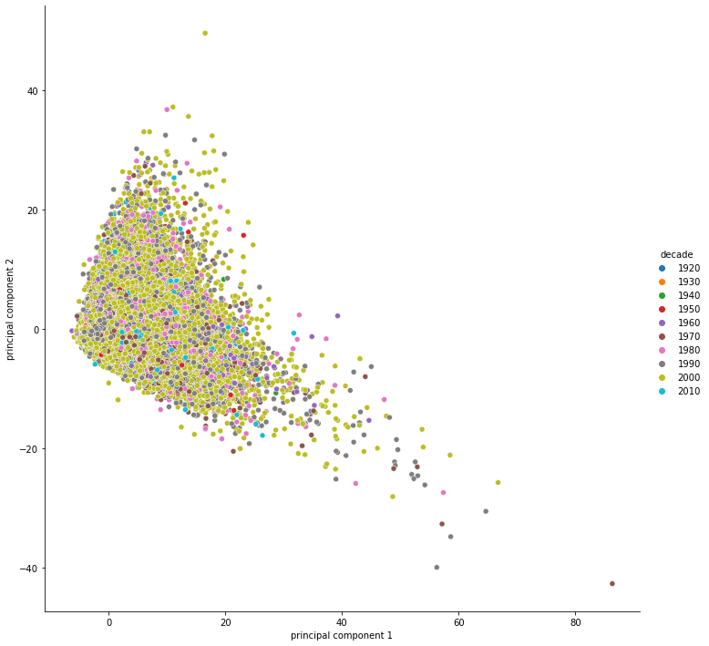

```python
pca = PCA(n_components = 2)
principalComponents = pca.fit_transform(scaled_train_features)
principalDf = pd.DataFrame(data = principalComponents,
                           columns = ['principal component 1', 'principal component 2'])
finalDf = pd.concat([principalDf, train_filtered[['decade']]], axis = 1)
sns.pairplot(finalDf,
             hue="decade",
             x_vars="principal component 1",
             y_vars="principal component 2",
             height=10)
```

We chose to visualize decade instead of year for ease of viewing. It is clear that PCA has not done a good job of isolating the informaiton to separate the classes. Perhaps this is because we included a lot of features that we knew were not linear.

Let's try again with the subset of features that had higher correlation.

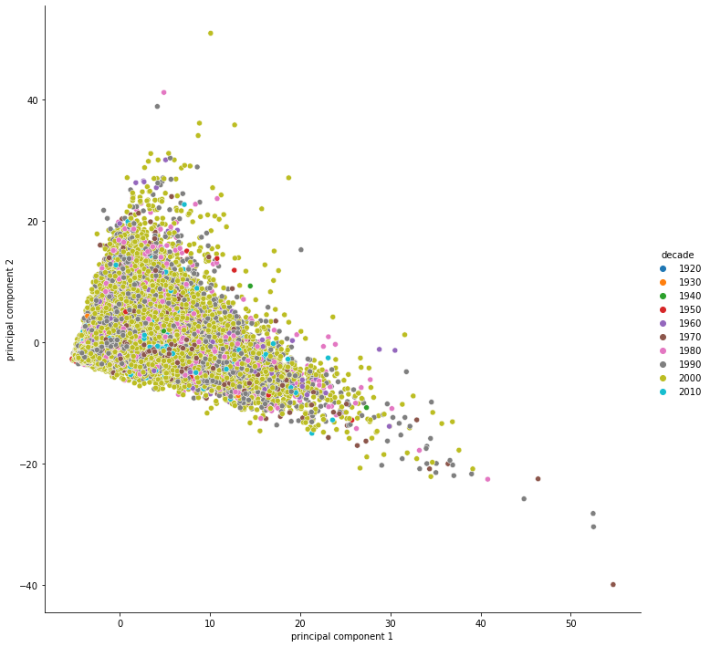

```python
#subset to features that look linear per pearson corr

train_features_linear = train_filtered[linear_features]

scaled_train_features_linear = StandardScaler().fit_transform(train_features_linear)

principalComponents_lin = pca.fit_transform(scaled_train_features_linear)
principaldf_lin = pd.DataFrame(data = principalComponents_lin,
                           columns = ['principal component 1', 'principal component 2'])
finalDf_lin = pd.concat([principaldf_lin, train_filtered[['decade']]], axis = 1)
sns.pairplot(finalDf_lin,
             hue="decade",
             x_vars="principal component 1",
             y_vars="principal component 2",
             height=10)
```

It doesn't look much better. PCA does not appear to be successful in segmenting by decade, further indicating that there is not a linear relationship between the target and features.

We can try a non-linear technique later if dimension reduction becomes important for computatation time. For now, are other approaches to reduce computational time that we will explore below.

METHODOLOGY OPTIONS

As discussed, the goal of this analysis is to determine a few unique and defensible approaches to landing on a prediction of "year" given the features provided.

DATA PREP

We learned in the exploratory analysis that this is a high dimensional data set with 90 features and 78 unique classes (years). All variables are numeric so the only preprocessing we need to do is to standardize the dataset. While not all models require standardization, its a good practice to standardize so that models that are sensitive to variation in variables can be compared.

Additionally, the training data is too large to train in a reasonable amount of time. Therefore, to reduce computational time we will need a smaller training dataset. There are many sampling options.

We know that this is a highly imbalanced dataset. Some models handle class imbalance better than others. In the interest of being able to leverage one data set to compare multiple models we will not apply data resampling or balancing techniques such as oversampling, undersampling, or sythentic data generation. With a more thorough analysis, balancing techniques would be considered.

To simplify and to reduce computational time, we will use a random sampling of 10% of the training data and then we will create our Train and Test datasets. `X` represents the features that will be used to train the model. `y` represents the target variable, in this case, `year` but we have created a second target variable for `decade` in case we do not have enough information to predict the exact year, we may be able to reasonably predict the decade instead.

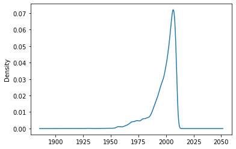

```python
train_10 = train_filtered.sample(frac=0.1, random_state=42) #randomly sample 10% of training data, set random state for repeatability

train_10.year.plot.density()
```

```python
train_features = train_10.iloc[:,1:91]
X_train = StandardScaler().fit_transform(train_features)
y_train_decade = train_10['decade']
y_train_year = train_10['year']

test_features = test_filtered.iloc[:,1:91]
X_test = StandardScaler().fit_transform(test_features)
y_test_decade = test_filtered['decade']
y_test_year = test_filtered['year']
```

FEATURE SELECTION / FEATURE ENGINEERING

We saw that PCA was ineffective in identifying variation between decades, so it is unlikely it would be useful for years. This is likely because the relationships are not linear.

Another approach for dimension reduction is to use Random Forest to get a sense of which features are most important. Random Forest handles non-linear relationships and high dimensionality effectively. However, it is sentistive to class imbalance and prone to overfit in instances of class imbalance. We can mitigate overfitting, and computational load, with a reduced number of trees.

```python
# Create the Random Forest Classifier with a reduced number of trees (e.g., 50 trees)
rf_model = RandomForestClassifier(n_estimators=50, random_state=42)
rf_model.fit(X_train, y_train_year)

# Get feature importances
feature_importances = rf_model.feature_importances_

# Create a DataFrame to display feature importances
feature_importance_df = pd.DataFrame({'Feature': train_features.columns, 'Importance': feature_importances})

# Sort the DataFrame by Importance in descending order
feature_importance_df = feature_importance_df.sort_values(by='Importance', ascending=False)

#create an array with the top ten features to potentially use for dimension reduction later
top10features = feature_importance_df.iloc[:10, :]['Feature'].array
```

[output not shown]

This seems like very low accuracy, but it is an improvement over randomly guessing. We also know that there are cover songs in the dataset that may be confusing the model. Additionally, running a model to classify to exact year means that if the model predicts 1995 but the song is from 1996, this is considered to be just as wrong as if the model was to classify the song into 1935. It's likely that asking the model to predict the decade, giving it a bit more leeway, would perform better and perhaps give us some insights into what features are more infortmative.

```python
# Use the trained model to make predictions on the test data
y_pred = rf_model.predict(X_test)

# Analyze the model's performance using various evaluation metrics
print("Accuracy:", accuracy_score(y_test_year, y_pred))
print("\nClassification Report:")
print(classification_report(y_test_year, y_pred, zero_division=0)) # setting zero division to 0 because there are samples with no predictions
```

```
Accuracy: 0.06970753437923688

Classification Report:
              precision    recall  f1-score   support

        1927       0.00      0.00      0.00         2
        1928       0.00      0.00      0.00         4
        1929       0.00      0.00      0.00        14
        1930       0.00      0.00      0.00         2
        1931       0.00      0.00      0.00         4
        1934       0.00      0.00      0.00         1
        1936       0.00      0.00      0.00         3
        1937       0.00      0.00      0.00         3
        1940       0.00      0.00      0.00        38
        1941       0.00      0.00      0.00         1
```

[output cut: 72 more lines]

Below we run random forest to predict the decade of the song instead of the year. While the accuracy is better, 60%, we still see that the model was unable to make any classifications for decades before 1970.

```python
# Create the Random Forest Classifier with a reduced number of trees (e.g., 50 trees)
rf_model_decade = RandomForestClassifier(n_estimators=50, random_state=42)
rf_model_decade.fit(X_train, y_train_decade)

# Use the trained model to make predictions on the test data
y_pred_decade = rf_model_decade.predict(X_test)

# Analyze the model's performance using various evaluation metrics
print("Accuracy:", accuracy_score(y_test_decade, y_pred_decade))
print("\nClassification Report:")
print(classification_report(y_test_decade, y_pred_decade, zero_division=0))
```

```
Accuracy: 0.6009103234553554

Classification Report:
              precision    recall  f1-score   support

        1920       0.00      0.00      0.00        20
        1930       0.00      0.00      0.00        13
        1940       0.00      0.00      0.00        61
        1950       0.00      0.00      0.00       275
        1960       0.00      0.00      0.00      1166
        1970       0.41      0.01      0.01      2396
        1980       0.52      0.03      0.07      4201
        1990       0.40      0.21      0.27     12580
        2000       0.63      0.94      0.76     29885
        2010       0.00      0.00      0.00      1033

    accuracy                           0.60     51630
   macro avg       0.20      0.12      0.11     51630
weighted avg       0.52      0.60      0.51     51630
```

Unfortunately, it seems futile to leverage the features deemed important by the random forest to reduce the dimensionality of the data set as it was unable to classify songs in any decades before 1970, nevermind the right years.

Given more time, we should work towards enhancing the data set with additional features that distinguish earlier decades from later decades. Additionally, as previously mentioned, applying balancing techniques may also improve the performance.

MODEL SELECTION

The Random Forest was useful to start out with because it is more easily explained than other, more powerful models. It may have also helped us to reduce our features by identifying the most important for distinguishing between years/decades.

However, with this dataset, it seems that we will need to trade interpretability for accuracy. There are many algorithm options to choose from and the goal of this analysis is not to find the best but instead to discuss a few options:

Reviewing the dataset and its limitations:

- Standardized Numeric
- Non-linear
- High dimensionality
- Multiple classes
- Highly imbalanced, especially for years in earlier decades

Some options to explore:

- XGBoost
- Support Vector Machine (SVM)

Let's discuss each method, then apply each to our year predictions.

XGBoost:

Even though we did not get great results with Random Forest, it worth trying XGBoost. Similar to Random Forest, XGBoost is a tree based algoriths. However, where Random Forest builds independent decision trees with random subsets of data and features, while XGBoost builds trees sequentially to correct errors made by previous trees. Random Forest uses majority voting to make predictions, whereas XGBoost uses a gradient boosting approach that optimizes a loss function by adding trees sequentially, minimizing errors and improving model accuracy. It prevents overfitting and handles high-dimensional data effectively.

As with any "black box" model, it is difficult to interpret and explain. It does provide importance for each feature. To really get XGBoost to shine, hyperparameter tuning is essential for optimal performance, which can be time-consuming and will not be considered in this analysis. It can also be quite computationally expensive, so we will minimize this by limiting trees and depth.

SVM (Support Vector Machine):

SVM aims to find the optimal hyperplane that best separates data points from different classes in a high-dimensional feature space. SVM works by transforming data points into a higher-dimensional space using a kernel function to enable the linear separation of classes. The algorithm seeks to maximize the margin between the support vectors (data points closest to the decision boundary) from different classes, making SVM robust against overfitting.

As with XGBoost, it can be difficult to interpret and explain the results. Computational time can be slow on large or imbalanced data sets and it can be sentitative to performance issues on unbalanced data.

It's difficult to say which model will perform better on our dataset, especially as both models are quite sensitive to hyperparamter tuning. We will not be doing that in this analysis but will run both models on year to see what results we can get on the first pass.

Label encoding assigns a unique integer to each category in a categorical feature. This is a necessary preprocessing step for both XGBoost and SVM.

```python
# Assuming 'y' contains the target variable with year labels

# Initialize the LabelEncoder
label_encoder = LabelEncoder()

# Fit and transform the target variable 'y' to encode it as consecutive integers
y_encoded = label_encoder.fit_transform(y_train_year)

# Display the unique classes after encoding
print("Unique classes after encoding:", np.unique(y_encoded))

# Assuming 'y' contains the target variable with year labels

y_encoded_test = label_encoder.fit_transform(y_test_year)

# Display the unique classes after encoding
print("Unique classes after encoding:", np.unique(y_encoded_test))

label_mapping_df = pd.DataFrame({
    'Original_Label': label_encoder.classes_,
    'Numerical_Code': label_encoder.transform(label_encoder.classes_)
})

label_mapping_df
```

```
Unique classes after encoding: [ 0  1  2  3  4  5  6  7  8  9 10 11 12 13 14 15 16 17 18 19 20 21 22 23
 24 25 26 27 28 29 30 31 32 33 34 35 36 37 38 39 40 41 42 43 44 45 46 47
 48 49 50 51 52 53 54 55 56 57 58 59 60 61 62 63 64 65 66 67 68 69 70 71
 72 73 74 75 76 77]
Unique classes after encoding: [ 0  1  2  3  4  5  6  7  8  9 10 11 12 13 14 15 16 17 18 19 20 21 22 23
 24 25 26 27 28 29 30 31 32 33 34 35 36 37 38 39 40 41 42 43 44 45 46 47
 48 49 50 51 52 53 54 55 56 57 58 59 60 61 62 63 64 65 66 67 68 69 70 71
 72 73 74 75 76 77]
```

|  | Original_Label | Numerical_Code |
| --- | --- | --- |
| 0 | 1927 | 0 |
| 1 | 1928 | 1 |
| 2 | 1929 | 2 |
| 3 | 1930 | 3 |
| 4 | 1931 | 4 |
| ... | ... | ... |
| 73 | 2006 | 73 |
| 74 | 2007 | 74 |
| 75 | 2008 | 75 |
| 76 | 2009 | 76 |
| 77 | 2010 | 77 |

78 rows × 2 columns

```python
# if not running on Macbook with GPU do not run this step

import os
os.environ["XGBOOST_BUILD_WITH_GPU"] = "1"
```

```python
xgb_model = xgb.XGBClassifier(
    objective='multi:softmax',  # For multiclass classification
    num_class=78,               # Number of classes
    n_estimators=50,            # Number of boosting rounds (trees)
    max_depth=3,                # Maximum depth of each tree
    learning_rate=0.1,          # Learning rate (step size for each iteration)
    random_state=42
)

# Train the XGBoost model
xgb_model.fit(X_train, y_encoded)
```

```
XGBClassifier(base_score=None, booster=None, callbacks=None,
              colsample_bylevel=None, colsample_bynode=None,
              colsample_bytree=None, early_stopping_rounds=None,
              enable_categorical=False, eval_metric=None, feature_types=None,
              gamma=None, gpu_id=None, grow_policy=None, importance_type=None,
              interaction_constraints=None, learning_rate=0.1, max_bin=None,
              max_cat_threshold=None, max_cat_to_onehot=None,
              max_delta_step=None, max_depth=3, max_leaves=None,
              min_child_weight=None, missing=nan, monotone_constraints=None,
              n_estimators=50, n_jobs=None, num_class=78,
              num_parallel_tree=None, objective='multi:softmax', ...)
```

```python
#make predictions with XGB
xgb_predictions = xgb_model.predict(X_test)
```

```python
accuracy = accuracy_score(y_encoded_test, xgb_predictions)
print("Accuracy:", accuracy)

print("Classification Report:")
print(classification_report(y_encoded_test, xgb_predictions, zero_division=0))

print("Confusion Matrix:")
print(confusion_matrix(y_encoded_test, xgb_predictions))
```

```
Accuracy: 0.07933372070501646
Classification Report:
              precision    recall  f1-score   support

           0       0.00      0.00      0.00         2
           1       0.00      0.00      0.00         4
           2       0.00      0.00      0.00        14
           3       0.00      0.00      0.00         2
           4       0.00      0.00      0.00         4
           5       0.00      0.00      0.00         1
           6       0.00      0.00      0.00         3
           7       0.00      0.00      0.00         3
           8       0.00      0.00      0.00        38
           9       0.00      0.00      0.00         1
          10       0.00      0.00      0.00         3
```

[output cut: 73 more lines]

[output not shown]

Next we run the SVM model.

```python
from sklearn.svm import SVC
svm_model = SVC(kernel='rbf',     # for non-linear
                C=1.0,            # Regularization parameter (default=1.0)
                random_state=42
)

# Train the SVM model
svm_model.fit(X_train, y_encoded)
```

```
SVC(random_state=42)
```

```python
# Make predictions with SVM
svm_predictions = svm_model.predict(X_test)
```

```python
accuracy = accuracy_score(y_encoded_test, svm_predictions)
print("Accuracy:", accuracy)

print("Classification Report:")
print(classification_report(y_encoded_test, svm_predictions, zero_division=0))

print("Confusion Matrix:")
print(confusion_matrix(y_encoded_test, svm_predictions))
```

```
Accuracy: 0.08355607205113307
Classification Report:
              precision    recall  f1-score   support

           0       0.00      0.00      0.00         2
           1       0.00      0.00      0.00         4
           2       0.00      0.00      0.00        14
           3       0.00      0.00      0.00         2
           4       0.00      0.00      0.00         4
           5       0.00      0.00      0.00         1
           6       0.00      0.00      0.00         3
           7       0.00      0.00      0.00         3
           8       0.00      0.00      0.00        38
           9       0.00      0.00      0.00         1
          10       0.00      0.00      0.00         3
```

[output cut: 80 more lines]

In summary, Random Forest Accuracy was 6.97%, XGBoost Accuracy was 7.93%, and SVM Accuracy was 8.36%. Although SVM and XGBoost models performed slightly better, they are far more computationally expensive and it seems unlikely that the additional gain of just 1-2% accuracy would be worth the cost. However, without knowing the use case for the model, it is difficult to evaluate which model, if any, would be best for tuning further.

Unfortunately, we saw from the beginning exploratory analysis that the data is highly imbalanced and that timbre alone does not seem to distinguish differences between years or even decades. Music from later decades tends to both mirror and expand upon the timbres of music from earlier decades. This makes it difficult for the model to classify. We also learned from researching the original data set that there are many cover songs in the dataset, which likely have similar timbre to the original song. These would also confuse the model and should be idenitified and labeled.

In order to improve the accuracy (or precision/recall -- depending on the use case), getting a better understanding of the original dataset would be beneficial. It is likely that timbre alone is not enough information about a song to accurately map it back to its decade, nevermind specific year. There are other features within the original Million Song Dataset that may be more useful in helping to identify songs that are misclassified and increase the overall accuracy.

Additionally, we should work specifically towards enhancing the data set with additional features that distinguish earlier decades from later decades, or consider isolating the dataset beyond 1970.

In the short term, Random Forest is far less computationally intensive and can be levearged to quickly understanding the impact of any feature generation or modifiation of the data set by simply limiting the number of trees.

When dealing with standardized numeric, non-linear, high-dimensional, multi-class, and highly imbalanced data, it's also important to preprocess the data appropriately for each model. This may include applying techniques to handle class imbalance, and definitely requires more careful tuning of hyperparameters for each model. This analysis did not attempt to tune any parameters beyond the initial run where the model was adjusted to limit computational time, likely at the expense of performance.